# Appendix 2 Exploratory Stuff

```r
library(readr)
library(alr4)
library(dplyr)
day <- read_csv("~/126 Regression/Bike-Sharing-Dataset/day.csv")
```

# Preliminary observations

Welcome to the capital bike share data set. Today we will be exploring the relationship between different variables and how they impact total bike count in future settings..  
Before we dive into exploratory data analysis, we will vet the data for any irregularites and remove them as fit.

[output not shown]

This tells us we have other responses we must remove. The other responses are: casual and registered. In addtion to removing those, we will get rid of non-variables. Our motivation is to predict count for future years, thus we must remove the categorical variable, year.

```r
day <- select(day,  c(- casual, - registered, - instant, - dteday, -yr) )
y <- day$cnt
test0 <- lm( y ~ . - cnt ,   data = day )
summary(test0)
```

```
##
## Call:
## lm(formula = y ~ . - cnt, data = day)
##
## Residuals:
##     Min      1Q  Median      3Q     Max
## -4278.2  -973.0  -190.1  1056.6  4006.7
##
## Coefficients:
##             Estimate Std. Error t value Pr(>|t|)
## (Intercept)  3033.31     360.95   8.404 2.30e-16 ***
## season        482.12      84.11   5.732 1.46e-08 ***
## mnth          -29.27      26.23  -1.116   0.2649
## holiday      -479.95     308.83  -1.554   0.1206
## weekday        61.35      25.04   2.450   0.0145 *
## workingday    112.39     110.62   1.016   0.3099
## weathersit   -494.64     120.24  -4.114 4.35e-05 ***
## temp         2381.14    2156.21   1.104   0.2698
## atemp        3634.09    2441.58   1.488   0.1371
## hum         -2234.15     478.65  -4.668 3.63e-06 ***
## windspeed   -3145.35     700.33  -4.491 8.25e-06 ***
## ---
## Signif. codes:  0 '***' 0.001 '**' 0.01 '*' 0.05 '.' 0.1 ' ' 1
##
## Residual standard error: 1340 on 720 degrees of freedom
## Multiple R-squared:  0.528,  Adjusted R-squared:  0.5214
## F-statistic: 80.53 on 10 and 720 DF,  p-value: < 2.2e-16
```

From the summary everything appears to be fine, but futher we are going to check for redundant variables using VIF. If there are two varaibles with a high correlation, then one must be removed, preferably the one with the higher number.

```r
vif(test0)
```

```
##     season       mnth    holiday    weekday workingday weathersit
##   3.547489   3.332573   1.083084   1.023842   1.076379   1.744807
##       temp      atemp        hum  windspeed
##  63.317230  64.343265   1.888988   1.197228
```

Since atemp has the highest co-variances, we will remove it.

```r
day <- select(day,  c(- atemp, - cnt ))
test0 <- lm( y ~ . , data = day )
vif(test0)
```

```
##     season       mnth    holiday    weekday workingday weathersit
##   3.540512   3.331034   1.081396   1.021227   1.076325   1.737620
##       temp        hum  windspeed
##   1.210200   1.875768   1.163155
```

Now that the data has been cleared of any non-variables, other potiental responses, and redundacies, we can continue to exploratory data analysis.

## Exploratory Data Analysis

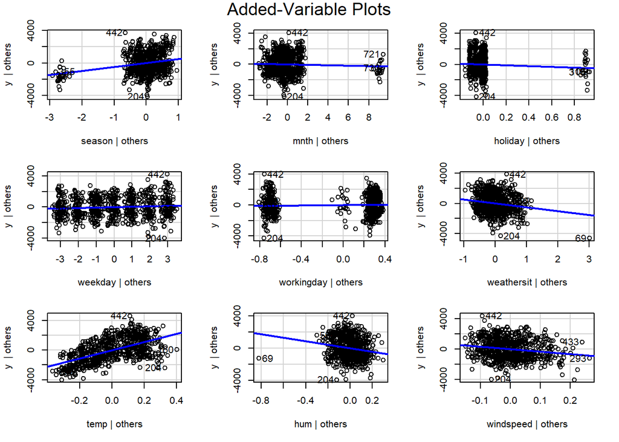

```r
avPlots(test0)
```

Here we view that the most impactful vairbale is tempature. The other variables do have correlations, but not as much as temp.

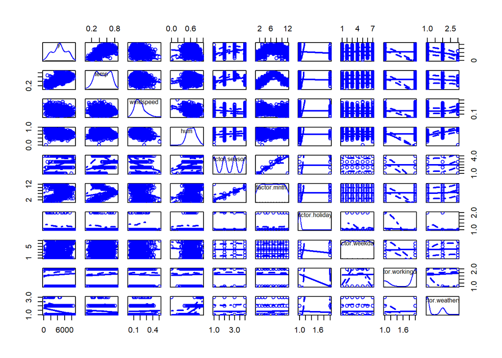

```r
scatterplotMatrix(~ y + temp + windspeed + hum + factor(season) + factor(mnth) + factor(holiday) + factor(weekday) + factor(workingday) + factor(weathersit) , data =day)
```

This is ugly but as we see there must be transformations in order to attain a correlation between predictors and the response.

### Diagnostics

```r
test1 <- test0
summary(test1)
```

```
##
## Call:
## lm(formula = y ~ ., data = day)
##
## Residuals:
##     Min      1Q  Median      3Q     Max
## -4209.1  -987.7  -170.3  1043.1  4053.6
##
## Coefficients:
##             Estimate Std. Error t value Pr(>|t|)
## (Intercept)  3193.23     344.87   9.259  < 2e-16 ***
## season        487.67      84.09   5.799 9.97e-09 ***
## mnth          -30.11      26.25  -1.147   0.2517
## holiday      -498.10     308.85  -1.613   0.1072
## weekday        59.46      25.02   2.376   0.0177 *
## workingday    111.22     110.71   1.005   0.3154
## weathersit   -506.12     120.10  -4.214 2.82e-05 ***
## temp         5559.67     298.35  18.635  < 2e-16 ***
## hum         -2174.55     477.37  -4.555 6.14e-06 ***
## windspeed   -3321.20     690.87  -4.807 1.86e-06 ***
## ---
## Signif. codes:  0 '***' 0.001 '**' 0.01 '*' 0.05 '.' 0.1 ' ' 1
##
## Residual standard error: 1341 on 721 degrees of freedom
## Multiple R-squared:  0.5265, Adjusted R-squared:  0.5206
## F-statistic: 89.08 on 9 and 721 DF,  p-value: < 2.2e-16
```

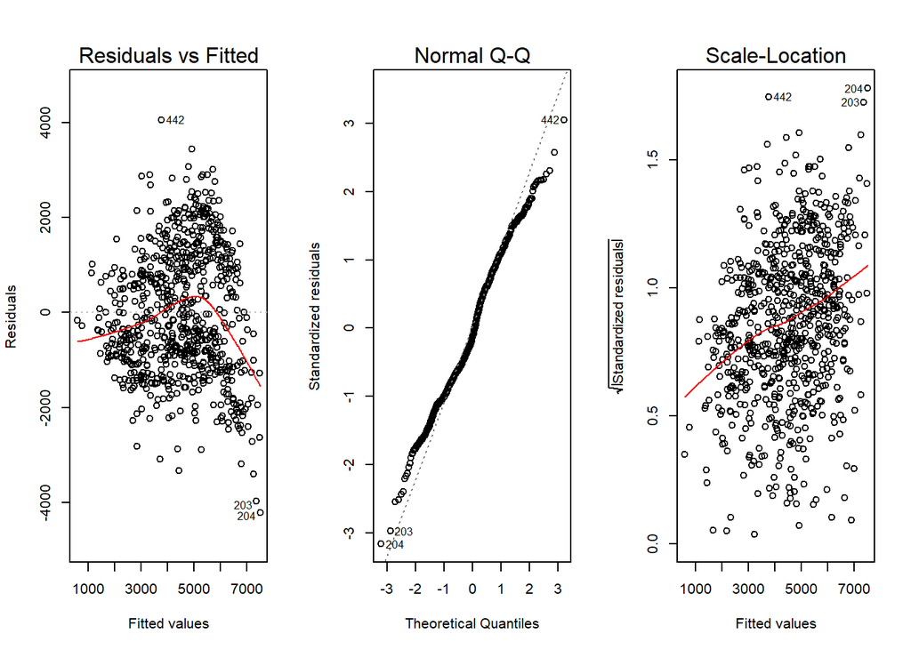

```r
par(mfrow = c( 1, 3))
for( i in 1:3){
  plot( test1 , which = i)}
```

```r
par(mfrow = c( 1, 1))
```

The residuals vs fitted and scale-location plot needs work. To this we will use MLR transformation. First checking if we need to add a constant to any numeric variable(need non-zero numbers for transformation).

```r
min(day$temp)
```

```
## [1] 0.0591304
```

```r
min(day$windspeed)
```

```
## [1] 0.0223917
```

```r
min(day$hum)
```

```
## [1] 0
```

Since humidity has value of zero we must add a constant before we proceed.

```r
day$hum1 <- with(day, (hum + .001 ))
diag1  <-  powerTransform(cbind(hum1, windspeed , temp) ~ 1, day)
summary(diag1)
```

```
## bcPower Transformations to Multinormality
##           Est Power Rounded Pwr Wald Lwr Bnd Wald Upr Bnd
## hum1         0.9971         1.0       0.8058       1.1885
## windspeed    0.4357         0.5       0.2993       0.5721
## temp         0.8385         1.0       0.6580       1.0190
##
## Likelihood ratio test that transformation parameters are equal to 0
##  (all log transformations)
##                                LRT df       pval
## LR test, lambda = (0 0 0) 677.8528  3 < 2.22e-16
##
## Likelihood ratio test that no transformations are needed
##                                LRT df       pval
## LR test, lambda = (1 1 1) 64.12643  3 7.7161e-14
```

Adding a small constant that will have a small impact on the data we find that windspeed, should have a square root transformation.

```r
testTransform(diag1, lambda = c(1, .5, 1))
```

```
##                                  LRT df    pval
## LR test, lambda = (1 0.5 1) 3.818622  3 0.28173
```

Following with the proceedures from the MLS pdf we have:

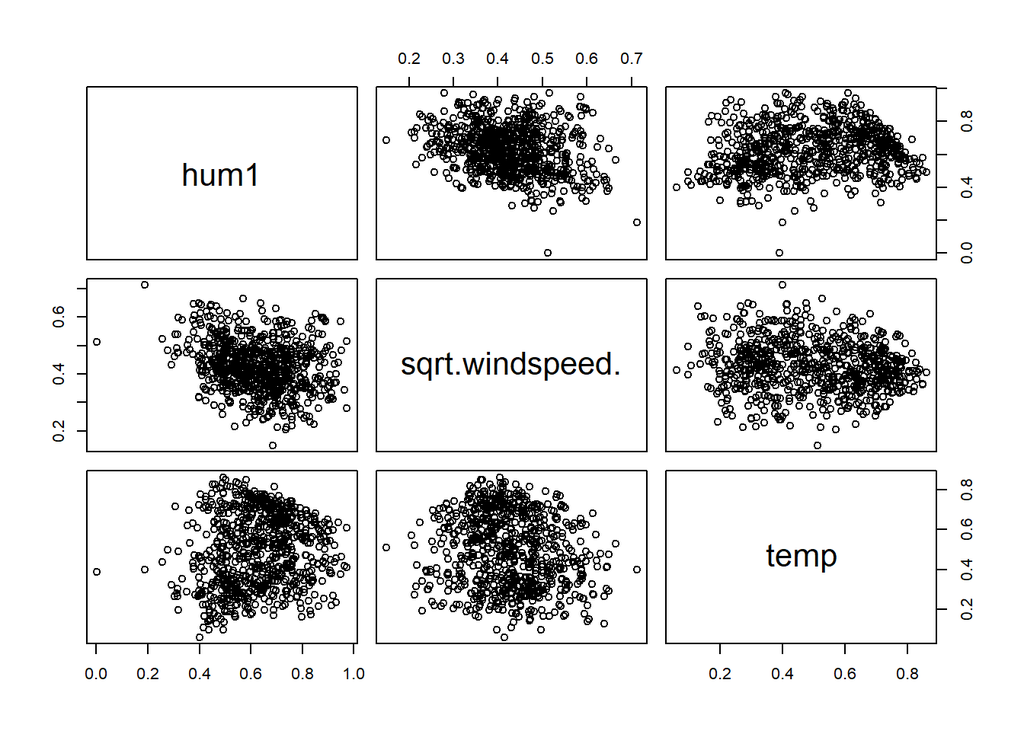

```r
day_trsf <- with(day, data.frame( hum1 , sqrt(windspeed), temp ))
pairs(day_trsf)
```

```r
windspeed.sqrt <- sqrt(day$windspeed)
day <- cbind( day,  windspeed.sqrt )
day <- select(day , -c(hum, windspeed) )
```

In the plots we can see a grouping between the predictors at hand, because of this it is closer to a linear relationship.

Now that we have transformed our predictors, our data could follow linearity assumptions.

```r
test2 <- lm(y ~. , data = day)
summary(test2)
```

```
##
## Call:
## lm(formula = y ~ ., data = day)
##
## Residuals:
##     Min      1Q  Median      3Q     Max
## -4208.8  -979.5  -187.7  1047.6  4043.7
##
## Coefficients:
##                Estimate Std. Error t value Pr(>|t|)
## (Intercept)     3759.62     432.35   8.696  < 2e-16 ***
## season           487.95      84.16   5.798 1.00e-08 ***
## mnth             -31.32      26.27  -1.192   0.2336
## holiday         -502.09     309.07  -1.625   0.1047
## weekday           59.84      25.04   2.390   0.0171 *
## workingday       110.44     110.79   0.997   0.3192
## weathersit      -507.78     120.23  -4.223 2.72e-05 ***
## temp            5592.32     298.43  18.739  < 2e-16 ***
## hum1           -2163.07     477.94  -4.526 7.04e-06 ***
## windspeed.sqrt -2834.46     603.85  -4.694 3.21e-06 ***
## ---
## Signif. codes:  0 '***' 0.001 '**' 0.01 '*' 0.05 '.' 0.1 ' ' 1
##
## Residual standard error: 1342 on 721 degrees of freedom
## Multiple R-squared:  0.5258, Adjusted R-squared:  0.5199
## F-statistic: 88.83 on 9 and 721 DF,  p-value: < 2.2e-16
```

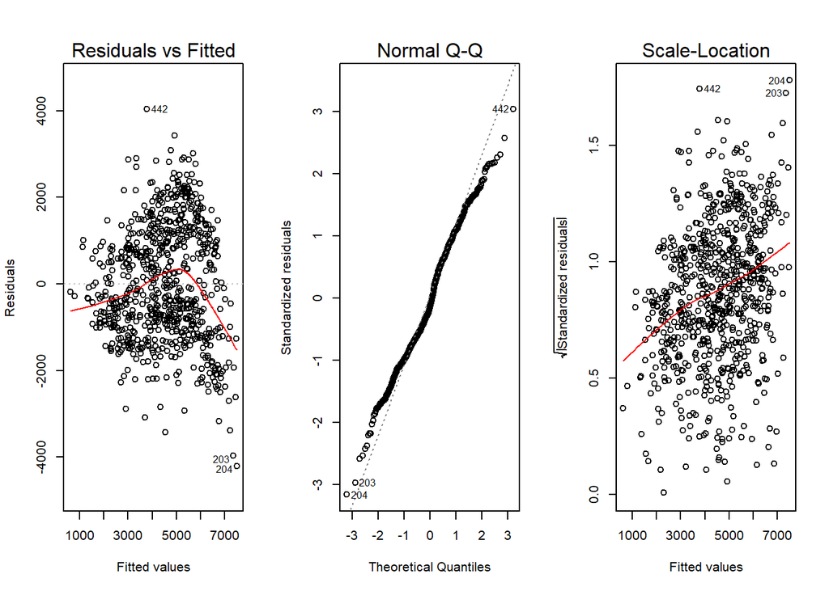

```r
par(mfrow = c( 1, 3))
for( i in 1:3){
  plot( test2 , which = i)

}
```

```r
par(mfrow = c( 1, 1))
```

There area still issues with all 3 of our plots, despite this since our data set is of length $n = 731$ the qq-plots do not have to be perfect.

In order to fix the violations in linearity-assumptions, we will consider a response transformation:

```r
bc <- boxCox(test2)
```

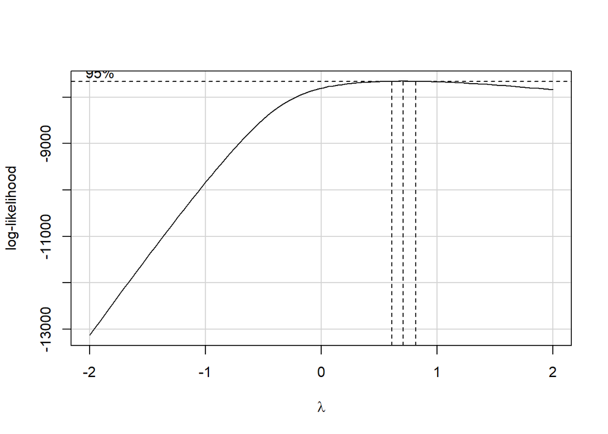

```r
lambda.opt <- bc$x[which.max(bc$y)]
lambda.opt
```

```
## [1] 0.7070707
```

Now the lambda is closest to .5, so we should transform our response with a square root.

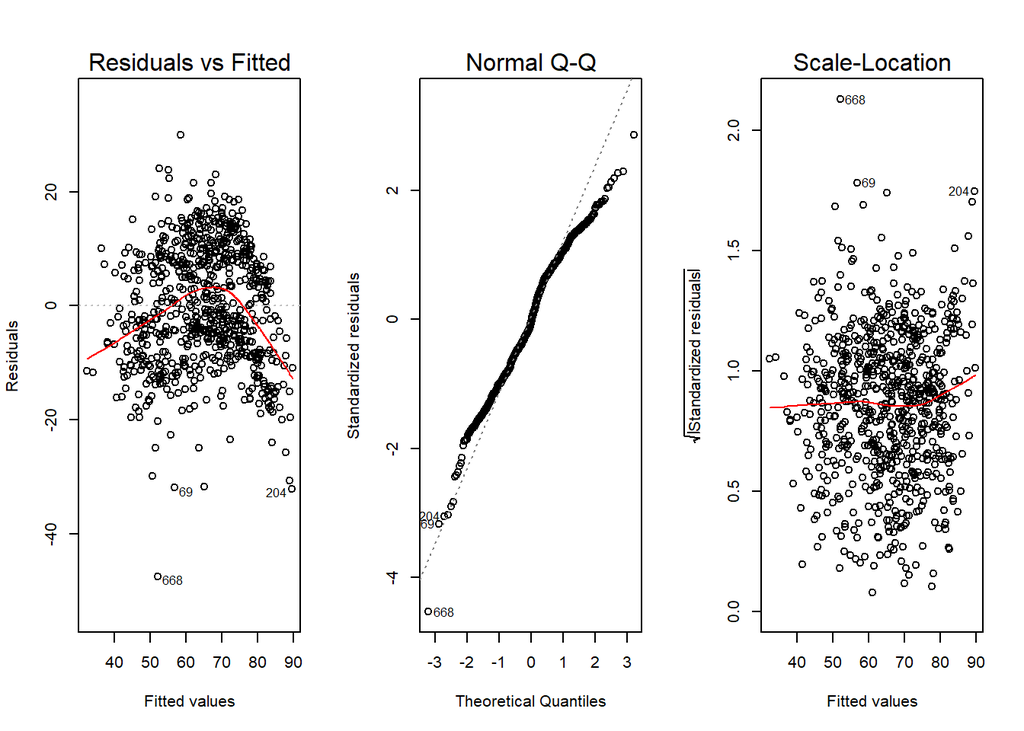

```r
y.sqrt <- sqrt(y)
test2 <- lm(y.sqrt ~ . , data = day)

par(mfrow = c( 1, 3))
for( i in 1:3){
  plot( test2 , which = i)

}
```

```r
par(mfrow = c( 1, 1))
```

Here we see that our plots are close to following linear assumptions. With nothing else to do we can continue to the AIC/BIC methods.

### AIC/BIC Model selection.

Doing the AIC/ BIC Methods, we have:

```r
#Inital model
m0 = lm(y.sqrt ~ temp , day)

#Full model
f = ~ season  + mnth + holiday + weekday + workingday + weathersit + temp + hum1 + windspeed.sqrt
#AIC method
m.forward = step(m0 , f ,direction = 'forward' )
```

```
## Start:  AIC=3649.95
## y.sqrt ~ temp
##
##                  Df Sum of Sq    RSS    AIC
## + weathersit      1   10029.5  97125 3580.1
## + season          1    8980.4  98174 3588.0
## + hum1            1    5948.3 101206 3610.2
## + mnth            1    4355.4 102799 3621.6
## + windspeed.sqrt  1    3660.3 103494 3626.5
## + weekday         1     610.4 106544 3647.8
## + holiday         1     555.6 106599 3648.1
## <none>                        107155 3649.9
## + workingday      1     251.7 106903 3650.2
##
## Step:  AIC=3580.11
## y.sqrt ~ temp + weathersit
##
##                  Df Sum of Sq   RSS    AIC
## + season          1   10270.3 86855 3500.4
## + mnth            1    5392.9 91732 3540.4
## + windspeed.sqrt  1    3415.5 93710 3555.9
## + weekday         1     775.9 96349 3576.2
## + holiday         1     752.6 96373 3576.4
## + workingday      1     517.2 96608 3578.2
## + hum1            1     384.7 96740 3579.2
## <none>                        97125 3580.1
##
## Step:  AIC=3500.41
## y.sqrt ~ temp + weathersit + season
##
##                  Df Sum of Sq   RSS    AIC
## + windspeed.sqrt  1   1472.47 85382 3489.9
## + hum1            1   1413.54 85441 3490.4
## + weekday         1    805.60 86049 3495.6
## + holiday         1    760.41 86095 3496.0
## + workingday      1    563.55 86291 3497.7
## + mnth            1    312.23 86543 3499.8
## <none>                        86855 3500.4
##
## Step:  AIC=3489.91
```

[output cut: 31 more lines]

```
## y.sqrt ~ temp + weathersit + season + windspeed.sqrt + hum1 +
##     holiday + weekday
##
##              Df Sum of Sq   RSS    AIC
## + workingday  1    225.33 81357 3462.6
## <none>                    81583 3462.6
## + mnth        1    214.90 81368 3462.7
##
## Step:  AIC=3462.61
## y.sqrt ~ temp + weathersit + season + windspeed.sqrt + hum1 +
##     holiday + weekday + workingday
##
##        Df Sum of Sq   RSS    AIC
## <none>              81357 3462.6
## + mnth  1    209.39 81148 3462.7
```

This gives us 8 variables to use.

Now with the BIC method

```r
n=731
step(m0, f, direction = 'forward', k = log(n), trace = 0)
```

```
##
## Call:
## lm(formula = y.sqrt ~ temp + weathersit + season + windspeed.sqrt +
##     hum1, data = day)
##
## Coefficients:
##    (Intercept)            temp      weathersit          season
##         60.641          46.560          -4.313           3.517
## windspeed.sqrt            hum1
##        -23.188         -17.998
```

The BIC method leaves us with 5 variables . In addition to this I calculated goodness of fit by hand and it was 16.6.

Copying and pasting the results from both:

```r
BIC <- lm(formula = y.sqrt ~ temp + weathersit + season + windspeed.sqrt + hum1, data = day)
AIC <- lm(y.sqrt ~ temp + weathersit + season + windspeed.sqrt + hum1 + holiday + weekday + workingday , data = day)
anova(BIC, AIC)
```

```
## Analysis of Variance Table
##
## Model 1: y.sqrt ~ temp + weathersit + season + windspeed.sqrt + hum1
## Model 2: y.sqrt ~ temp + weathersit + season + windspeed.sqrt + hum1 +
##     holiday + weekday + workingday
##   Res.Df   RSS Df Sum of Sq      F   Pr(>F)
## 1    725 82781
## 2    722 81357  3    1423.7 4.2115 0.005761 **
## ---
## Signif. codes:  0 '***' 0.001 '**' 0.01 '*' 0.05 '.' 0.1 ' ' 1
```

Must do BIC MLR diagnostics, then make the model plots, if still not good, make a non-parallel model.

In this chunk I will be usign the linear model BIC and factoring all categorical variables.

```r
BIC.factor <- lm(formula = y.sqrt ~ temp + factor(weathersit) + factor(season) + windspeed.sqrt + hum1 , data = day)
summary(BIC.factor)
```

```
##
## Call:
## lm(formula = y.sqrt ~ temp + factor(weathersit) + factor(season) +
##     windspeed.sqrt + hum1, data = day)
##
## Residuals:
##     Min      1Q  Median      3Q     Max
## -36.979  -7.049  -1.275   8.710  29.617
##
## Coefficients:
##                     Estimate Std. Error t value Pr(>|t|)
## (Intercept)          57.1083     3.3357  17.120  < 2e-16 ***
## temp                 51.4157     3.7249  13.803  < 2e-16 ***
## factor(weathersit)2  -1.6286     0.9891  -1.647   0.1001
## factor(weathersit)3 -19.6138     2.5300  -7.753 3.06e-14 ***
## factor(season)2       8.1372     1.3854   5.874 6.50e-09 ***
## factor(season)3       4.0548     1.8258   2.221   0.0267 *
## factor(season)4      13.0634     1.1839  11.035  < 2e-16 ***
## windspeed.sqrt      -22.3666     4.5660  -4.898 1.19e-06 ***
## hum1                -20.5732     3.5761  -5.753 1.30e-08 ***
## ---
## Signif. codes:  0 '***' 0.001 '**' 0.01 '*' 0.05 '.' 0.1 ' ' 1
##
## Residual standard error: 10.06 on 722 degrees of freedom
## Multiple R-squared:  0.5971, Adjusted R-squared:  0.5926
## F-statistic: 133.7 on 8 and 722 DF,  p-value: < 2.2e-16
```

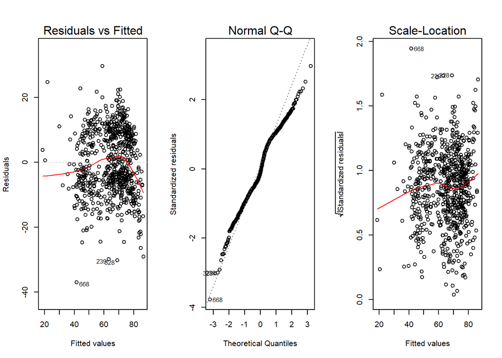

```r
par(mfrow = c( 1, 3))
for( i in 1:3){
  plot( BIC.factor , which = i)

}
```

```r
par(mfrow = c( 1,1))
```

Running a second diagnostic to see if we can transform and make residuals linear.

```r
diag2  <-  powerTransform(cbind(hum1, windspeed.sqrt , temp) ~ 1, day)
summary(diag2)
```

```
## bcPower Transformations to Multinormality
##                Est Power Rounded Pwr Wald Lwr Bnd Wald Upr Bnd
## hum1              0.9971           1       0.8058       1.1885
## windspeed.sqrt    0.8714           1       0.5986       1.1442
## temp              0.8385           1       0.6580       1.0190
##
## Likelihood ratio test that transformation parameters are equal to 0
##  (all log transformations)
##                                LRT df       pval
## LR test, lambda = (0 0 0) 677.8528  3 < 2.22e-16
##
## Likelihood ratio test that no transformations are needed
##                                LRT df    pval
## LR test, lambda = (1 1 1) 3.818622  3 0.28173
```

No futher transfermations are possible.

Thus we must consider a non-parallel model. After a lot of testing

```r
test3 <- lm(y.sqrt ~ temp* factor(weathersit)*factor(season) + hum1 + windspeed.sqrt, data = day  )
summary(test3)
```

```
##
## Call:
## lm(formula = y.sqrt ~ temp * factor(weathersit) * factor(season) +
##     hum1 + windspeed.sqrt, data = day)
##
## Residuals:
##     Min      1Q  Median      3Q     Max
## -31.829  -6.702  -0.208   7.925  22.185
##
## Coefficients:
##                                           Estimate Std. Error t value
## (Intercept)                                49.6957     3.8600  12.874
## temp                                       92.4099     8.0006  11.550
## factor(weathersit)2                        -0.6694     4.7210  -0.142
## factor(weathersit)3                        57.1681    19.2802   2.965
## factor(season)2                            25.9781     5.0637   5.130
## factor(season)3                            91.2291     9.1684   9.950
## factor(season)4                            18.0056     4.5489   3.958
## hum1                                      -27.4089     3.6001  -7.613
## windspeed.sqrt                            -25.8184     4.3060  -5.996
## temp:factor(weathersit)2                    2.9755    15.1669   0.196
## temp:factor(weathersit)3                 -269.7100    69.0138  -3.908
## temp:factor(season)2                      -48.5630    11.0007  -4.415
## temp:factor(season)3                     -145.2174    14.5518  -9.979
## temp:factor(season)4                      -20.4688    12.0006  -1.706
## factor(weathersit)2:factor(season)2        -9.6724     8.1597  -1.185
## factor(weathersit)3:factor(season)2       -37.0773    34.3558  -1.079
## factor(weathersit)2:factor(season)3       -56.3957    16.7933  -3.358
## factor(weathersit)3:factor(season)3       -40.1278    84.4093  -0.475
## factor(weathersit)2:factor(season)4        13.3726     7.6570   1.746
## factor(weathersit)3:factor(season)4       -96.2050    24.6115  -3.909
## temp:factor(weathersit)2:factor(season)2   11.2554    19.4106   0.580
## temp:factor(weathersit)3:factor(season)2  160.8610   103.0197   1.561
## temp:factor(weathersit)2:factor(season)3   77.1379    27.8527   2.769
## temp:factor(weathersit)3:factor(season)3  204.3366   154.6519   1.321
## temp:factor(weathersit)2:factor(season)4  -35.5306    20.3789  -1.743
## temp:factor(weathersit)3:factor(season)4  305.6192    76.6710   3.986
##                                          Pr(>|t|)
## (Intercept)                               < 2e-16 ***
## temp                                      < 2e-16 ***
```

[output cut: 15 more lines]

```
## factor(weathersit)3:factor(season)3      0.634652
## factor(weathersit)2:factor(season)4      0.081165 .
## factor(weathersit)3:factor(season)4      0.000102 ***
## temp:factor(weathersit)2:factor(season)2 0.562195
## temp:factor(weathersit)3:factor(season)2 0.118864
## temp:factor(weathersit)2:factor(season)3 0.005762 **
## temp:factor(weathersit)3:factor(season)3 0.186841
## temp:factor(weathersit)2:factor(season)4 0.081682 .
## temp:factor(weathersit)3:factor(season)4 7.42e-05 ***
## ---
## Signif. codes:  0 '***' 0.001 '**' 0.01 '*' 0.05 '.' 0.1 ' ' 1
##
## Residual standard error: 9.261 on 705 degrees of freedom
## Multiple R-squared:  0.6664, Adjusted R-squared:  0.6546
## F-statistic: 56.33 on 25 and 705 DF,  p-value: < 2.2e-16
```

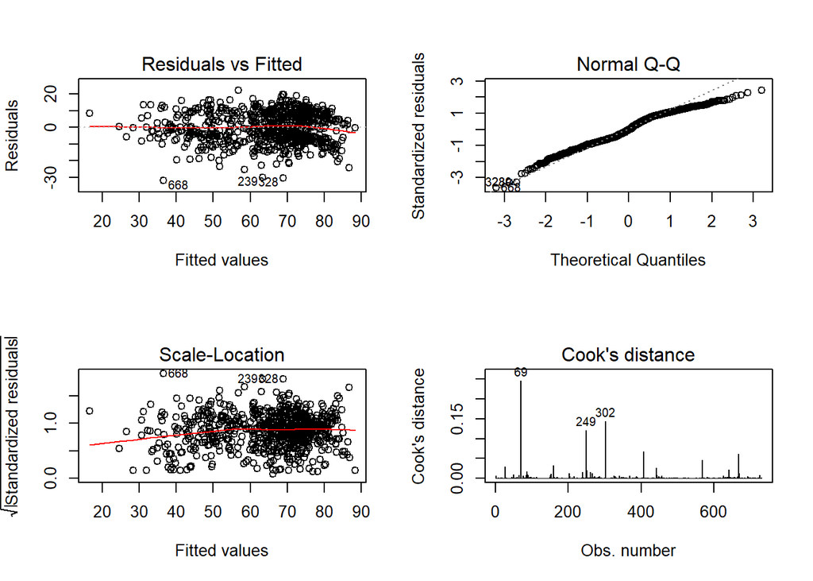

```r
par(mfrow = c(2,2))
for( i in 1:4){
  plot(test3 , which = i )
}
```

```r
par(mfrow = c(1,1))
```

In addition, we will verify it is the best

```r
anova(BIC.factor, test3 )
```

```
## Analysis of Variance Table
##
## Model 1: y.sqrt ~ temp + factor(weathersit) + factor(season) + windspeed.sqrt +
##     hum1
## Model 2: y.sqrt ~ temp * factor(weathersit) * factor(season) + hum1 +
##     windspeed.sqrt
##   Res.Df   RSS Df Sum of Sq     F    Pr(>F)
## 1    722 73031
## 2    705 60466 17     12565 8.618 < 2.2e-16 ***
## ---
## Signif. codes:  0 '***' 0.001 '**' 0.01 '*' 0.05 '.' 0.1 ' ' 1
```

Since we have such a small p-value for model2, we reject that the slope of non-parallel interactions are 0, arriving at our final model.